# ECOM30004/90004 Time Series Analysis and Forecasting Tutorial 6 Tutor: Pengyun (Kevin) Chen University of Melbourne Semester 2, 2026

## Notice

**Conditions of Use**

- This document is intended for personal use and is NOT meant to be shared on the internet (e.g. Studocu, ThinkSwap, StudentVIP, Coursehero, etc.)
- Do not share this document with anyone, even if they are enrolled in ECOM30004/90004.
- Official course materials, such as lecture slides, tutorial sheets and prescribed readings should always be your primary point of reference.
- Slides accessible here: `pengyunc.github.io/TSAF_Week6`
- Download HTML versions here: [Dropbox Link](https://www.dropbox.com/scl/fo/aoxoud5ex0j42hsrod3dg/ADblAt_jJ9hpESZME9FDcWc?rlkey=0s0oyf1y3uokzvlhbzxe2yy3g&st=kx2yupzr&dl=0)

## (BONUS) Opening HTML Files in RStudio (2/2)

Step 1: Set up your working directory containing HTML files:

```r
setwd("Your working directory goes here")
```

Step 2: Define the following function once:

```r
# Copy everything below into the console window and run it:
openfile <- function(src) {
  tmp_dir <- tempfile()
  dir.create(tmp_dir)
  tmp_html <- file.path(tmp_dir, basename(src))
  file.copy(src, tmp_html, overwrite = TRUE)
  rstudioapi::viewer(tmp_html)
}
```

Step 3: Call this function with file name as character string:

```r
# Just a few examples here:
openfile("Lecture5.html")
openfile("Tutorial6.html")
openfile("ECOM30004_Tutorial_6_Slides.html")
```

## This tutorial

In this tutorial, we demonstrate forecasting the 2020Q1 CPI level, including stationarity tests, ARIMA model selection, and the final forecast computation.

**Agenda**

- Exercise 1(a): Transform CPI levels into log differences and select the ADF specification.
- Exercise 1(b): Test the log-differenced CPI for a unit root (ADF).
- Exercise 1(c): Select the ARIMA model using AICc and Ljung–Box diagnostics.
- Exercise 1(d): Does the choice of using observation indices or observation dates matter?
- Exercise 1(e): Forecast inflation and CPI for 2020Q1.
- Exercise 2: Rearranging a time series model into its corresponding ADF test equation.

## We know that taking the logs is not enough…

Recall the unit root test results for log `CPI` from Self-directed Activities 5.

```r
dt <- read.csv("CPI.csv")
Y <- ts(log(dt$CPI), start = c(1922,2), end = c(2025,2), frequency=4)
Y <- window(Y, start = c(1946,1), end = c(2019,4))
```

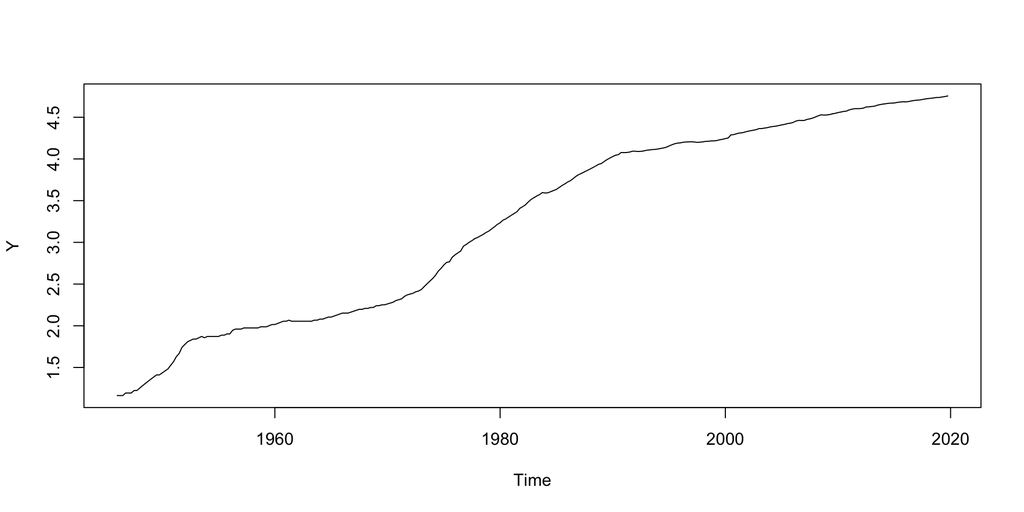

```r
plot(Y)
```

An upward trend is obvious $\to$ add a time trend in deterministic specification

## We know that taking the logs is not enough…

Carry out an ADF test of `Y`, present (i) the estimated test equation, (ii) the $t_{\text{ADF}}$ test statistic, 5% critical value and decision, and (iii) its $p$-value.

```r
library(urca)    # For use of ur.df function
adf <- ur.df(Y, type = "trend", selectlags = "AIC")
p_adf <- punitroot(adf@teststat[1], trend = "ct", statistic = "t")
```

- (i) test equation
- (ii) test summary
- (iii) $p$-value

The test equation is:
$$\Delta Y_{t}=\beta_{0}+\beta_{1}t+\varphi Y_{t-1}+\sum^{p-1}_{k=1}\psi_{k} \Delta Y_{t-k}+U_{t}$$
The hypotheses are:
$$\begin{align}
H_{0}:&\;\varphi=0& &\textsf{($Y_{t}$ has a unit root)}\\
H_{1}:&\;\varphi<0& &\textsf{($Y_{t}$ does not have a unit root)}
\end{align}$$
The number of lags of $\Delta Y_{t}$ (i.e., $p-1$) is selected by an information criterion (AIC), where $p$ is the order of the underlying AR model.

```r
summary(adf)
```

```
###############################################
# Augmented Dickey-Fuller Test Unit Root Test #
###############################################

Test regression trend


Call:
lm(formula = z.diff ~ z.lag.1 + 1 + tt + z.diff.lag)

Residuals:
      Min        1Q    Median        3Q       Max
-0.031901 -0.005565 -0.000645  0.004216  0.045287

Coefficients:
              Estimate Std. Error t value Pr(>|t|)
(Intercept)  8.657e-03  3.805e-03   2.275   0.0236 *
z.lag.1      2.743e-04  2.772e-03   0.099   0.9212
tt          -2.428e-05  3.733e-05  -0.651   0.5159
z.diff.lag   5.147e-01  5.049e-02  10.193   <2e-16 ***
---
Signif. codes:  0 '***' 0.001 '**' 0.01 '*' 0.05 '.' 0.1 ' ' 1

Residual standard error: 0.01025 on 290 degrees of freedom
Multiple R-squared:  0.3263,    Adjusted R-squared:  0.3193
F-statistic: 46.82 on 3 and 290 DF,  p-value: < 2.2e-16


Value of test-statistic is: 0.099 16.8276 3.9857

Critical values for test statistics:
      1pct  5pct 10pct
tau3 -3.98 -3.42 -3.13
phi2  6.15  4.71  4.05
phi3  8.34  6.30  5.36
```

```r
print(p_adf)
```

```
[1] 0.9973104
```

Since $p=0.997>0.05$, we **fail to reject** the null hypothesis $H_{0}$: there is unit root.

$\implies$ Simply removing the trend component is not enough to make $Y_{t}$ stationary.

$\implies$ We need to take the first difference of log `CPI`.

## Exercise 1(a)

Next create the first difference time series $\Delta Y_{t}$ and a time series plot. Decide whether a trend is required for a unit root test for $\Delta Y_{t}$.

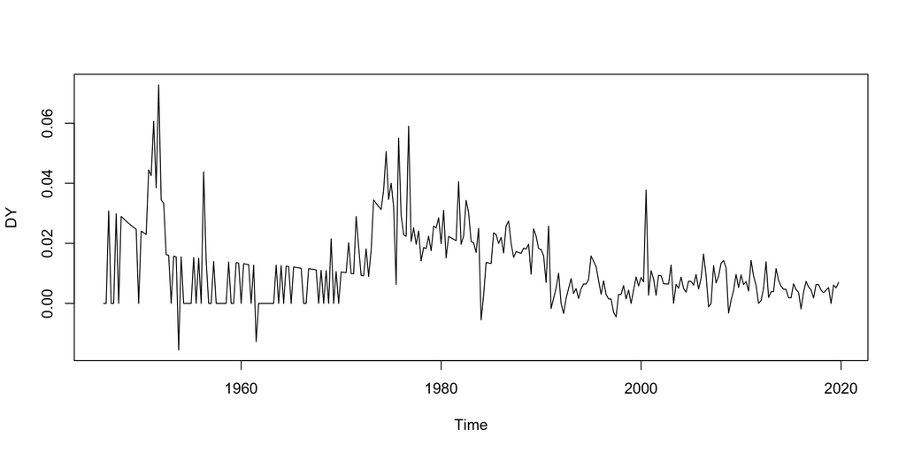

```r
DY <- diff(Y)   # DY is the log difference of the CPI -> Inflation
plot(DY)
```

**Observation:** There is no evidence of a linear trend in this time series. There are some extended periods (e.g. early 1950’s and 1970-80’s) when inflation was higher.

## Exercise 1(b)

Carry out the unit root test on $\Delta Y_{t}$. Conclude how many differences are required for log CPI to be stationary.

```r
adf <- ur.df(DY, type = "drift", selectlags = "AIC")
p_adf <- punitroot(adf@teststat[1], trend = "c", statistic = "t")
summary(adf)
```

```
###############################################
# Augmented Dickey-Fuller Test Unit Root Test #
###############################################

Test regression drift


Call:
lm(formula = z.diff ~ z.lag.1 + 1 + z.diff.lag)

Residuals:
      Min        1Q    Median        3Q       Max
-0.030300 -0.004863 -0.000533  0.003937  0.039013

Coefficients:
              Estimate Std. Error t value Pr(>|t|)
(Intercept)  0.0031901  0.0008224   3.879  0.00013 ***
z.lag.1     -0.2581651  0.0501006  -5.153 4.75e-07 ***
z.diff.lag  -0.4253700  0.0530437  -8.019 2.64e-14 ***
---
Signif. codes:  0 '***' 0.001 '**' 0.01 '*' 0.05 '.' 0.1 ' ' 1

Residual standard error: 0.009393 on 290 degrees of freedom
Multiple R-squared:  0.3652,    Adjusted R-squared:  0.3608
F-statistic: 83.41 on 2 and 290 DF,  p-value: < 2.2e-16


Value of test-statistic is: -5.1529 13.2782

Critical values for test statistics:
      1pct  5pct 10pct
tau2 -3.44 -2.87 -2.57
phi1  6.47  4.61  3.79
```

The estimated ADF test equation is:

$$\widehat{\Delta(\Delta Y_{t})}=0.0031-0.258\Delta Y_{t-1}-0.4253\Delta(\Delta Y_{t-1})$$

## Exercise 1(b)

Carry out the unit root test on $\Delta Y_{t}$. Conclude how many differences are required for log CPI to be stationary.

```r
adf <- ur.df(DY, type = "drift", selectlags = "AIC")
p_adf <- punitroot(adf@teststat[1], trend = "c", statistic = "t")
summary(adf)
```

```
###############################################
# Augmented Dickey-Fuller Test Unit Root Test #
###############################################

Test regression drift


Call:
lm(formula = z.diff ~ z.lag.1 + 1 + z.diff.lag)

Residuals:
      Min        1Q    Median        3Q       Max
-0.030300 -0.004863 -0.000533  0.003937  0.039013

Coefficients:
              Estimate Std. Error t value Pr(>|t|)
(Intercept)  0.0031901  0.0008224   3.879  0.00013 ***
z.lag.1     -0.2581651  0.0501006  -5.153 4.75e-07 ***
z.diff.lag  -0.4253700  0.0530437  -8.019 2.64e-14 ***
---
Signif. codes:  0 '***' 0.001 '**' 0.01 '*' 0.05 '.' 0.1 ' ' 1

Residual standard error: 0.009393 on 290 degrees of freedom
Multiple R-squared:  0.3652,    Adjusted R-squared:  0.3608
F-statistic: 83.41 on 2 and 290 DF,  p-value: < 2.2e-16


Value of test-statistic is: -5.1529 13.2782

Critical values for test statistics:
      1pct  5pct 10pct
tau2 -3.44 -2.87 -2.57
phi1  6.47  4.61  3.79
```

The $t$-statistic is $-5.1529$, and the $5\%$ critical value is $-2.87$.

Since $-5.1539<-2.87$, we **reject** $H_0$: $\Delta Y_{t}$ has a unit root.

## Exercise 1(b)

Carry out the unit root test on $\Delta Y_{t}$. Conclude how many differences are required for log CPI to be stationary.

```r
adf <- ur.df(DY, type = "drift", selectlags = "AIC")
p_adf <- punitroot(adf@teststat[1], trend = "c", statistic = "t")
summary(adf)
```

The $t$-statistic is $-5.1529$, and the $5\%$ critical value is $-2.87$.

Since $-5.1539<-2.87$, we **reject** $H_0$: $\Delta Y_{t}$ has a unit root.

```r
print(p_adf)
```

```
[1] 9.828593e-06
```

Alternatively, since $p=9.82\times 10^{-6}<0.05$, we **reject $H_0$: $\Delta Y_{t}$ has a unit root**.

**Conclusion:** To render log CPI stationary, it is necessary to difference the series *once*.

## Exercise 1(c)

Specify and estimate an appropriate ARIMA($p,d,q$) model for $Y_{t}$.

- Since first differencing is required for log CPI to be stationary, we need $d=1$.
- How to select $(p,q)$? $\to$ Conduct a grid search for $p=0,\dots,4$ and $q=0,\dots,4$

**Code Structure**

- Set up container matrices for AICc values (`AICc`) and Ljung-Box test $p$-values (`LBp`)
- For each $(p,q)$ combination:
  - Fit the ARIMA($p,1,q$) model with `Arima()` function, and extract AICc
  - Extract the Ljung-Box $p$-values with `Box.test()` function
- Choose the model with the **lowest** AICc, and verify that its Ljung-Box $H_{0}$ (no autocorrelation) is not rejected.

## Exercise 1(c)

Specify and estimate an appropriate ARIMA($p,d,q$) model for $Y_{t}$.

- Since first differencing is required for log CPI to be stationary, we need $d=1$.
- How to select $(p,q)$? $\to$ Conduct a grid search for $p=0,\dots,4$ and $q=0,\dots,4$

```r
library(forecast)

pmax <- 4
qmax <- 4

LBp <- matrix(nrow=pmax+1, ncol=qmax+1)
rownames(LBp) <- paste0("p=", 0:pmax)
colnames(LBp) <- paste0("q=", 0:qmax)
AICc <- LBp

for (p in 0:pmax){
  for (q in 0:qmax){
    eq <- Arima(DY, order=c(p,0,q))
    LBp[p+1,q+1] <- Box.test(eq$residuals, lag = 8,
                             type = "Ljung-Box", fitdf = p+q)$p.value
    AICc[p+1,q+1] <- eq$aicc
  }
}
```

## Exercise 1(c)

Specify and estimate an appropriate ARIMA($p,d,q$) model for $Y_{t}$.

```r
print(LBp<0.05)
```

```
     q=0  q=1   q=2   q=3   q=4
p=0 TRUE TRUE  TRUE  TRUE  TRUE
p=1 TRUE TRUE FALSE FALSE FALSE
p=2 TRUE TRUE FALSE FALSE FALSE
p=3 TRUE TRUE FALSE FALSE FALSE
p=4 TRUE TRUE  TRUE FALSE  TRUE
```

Model to minimise AICc:

```r
print(AICc==min(AICc))
```

```
      q=0   q=1   q=2   q=3   q=4
p=0 FALSE FALSE FALSE FALSE FALSE
p=1 FALSE FALSE FALSE  TRUE FALSE
p=2 FALSE FALSE FALSE FALSE FALSE
p=3 FALSE FALSE FALSE FALSE FALSE
p=4 FALSE FALSE FALSE FALSE FALSE
```

**Conclusion:** The chosen model is ARMA($1,3$) for $\Delta Y_{t}$, equivalently ARIMA($1,1,3$) for $Y_{t}$.

## Exercise 1(c)

Model the linear trend using the observation indices $t=1,2,\dots,n$.

Combining a difference and a linear trend in the model requires some careful interpretation - write out the model in equation form and interpret the coefficients.

- ARIMA(1,0,3) on $\Delta Y_{t}$
- ARIMA(1,1,3) on $Y_{t}$
- Comments on Forecasting

To estimate the ARIMA(1,0,3) model for $\Delta Y_{t}$, with that difference already taken in computing `DY`:

```r
eq_a <- Arima(DY, order = c(1,0,3))
print(round(eq_a$coef,4))
```

```
      ar1       ma1       ma2       ma3 intercept
   0.8316   -0.6377    0.2380    0.1276    0.0120
```

In equation form, this estimated model can be written as:

$$\begin{align}
\Delta Y_{t}&=0.0120 +\widehat{\Delta Z}_{t}\\
\widehat{\Delta Z}_{t}&=0.8316\widehat{\Delta Z}_{t-1}+\widehat{U}_{t}-0.6377\widehat{U}_{t-1}+0.2380\widehat{U}_{t-2}+0.1276\widehat{U}_{t-3}
\end{align}$$

The intercept of the model, $\widehat{\beta}_{1}=0.0120$, implies the estimated mean rate of inflation is $0.0120$, or $1.2\%$ per quarter (this is a quarterly time series).

The same model may be estimated as an ARIMA($1,1,3$) model for $Y_{t}$:

```r
eq_b <- Arima(Y, order = c(1,1,3), include.drift = TRUE)
print(round(eq_b$coef,4))
```

```
    ar1     ma1     ma2     ma3   drift
 0.8316 -0.6377  0.2380  0.1276  0.0120
```

$$\begin{align}
Y_{t}&=0.0120t +\widehat{Z}_{t}\\
\widehat{\Delta Z}_{t}&=0.8316\widehat{\Delta Z}_{t-1}+\widehat{U}_{t}-0.6377\widehat{U}_{t-1}+0.2380\widehat{U}_{t-2}+0.1276\widehat{U}_{t-3}
\end{align}$$

**Note**

- `include.drift = TRUE` option is necessary for the inclusion of $\beta_{1}$ when the differencing is specified under `order = c(1,1,3)` rather than taking the difference beforehand and included in the model as `DY`.
- It is called “drift” because a constant in a first-differenced process corresponds to a linear trend in the level of $Y_{t}$.
- Alternatively, replicating this with `xreg` argument:

```r
t <- 1:length(Y)
eq_b_xreg <- Arima(Y, order = c(1,1,3), xreg = t)
print(round(eq_b_xreg$coef,4))
```

```
    ar1     ma1     ma2     ma3    xreg
 0.8316 -0.6377  0.2380  0.1276  0.0120
```

```r
print(round(eq_a$coef,4))
```

```
      ar1       ma1       ma2       ma3 intercept
   0.8316   -0.6377    0.2380    0.1276    0.0120
```

```r
print(round(eq_b$coef,4))
```

```
    ar1     ma1     ma2     ma3   drift
 0.8316 -0.6377  0.2380  0.1276  0.0120
```

- The two approaches are equivalent for estimation, as can be seen from these coefficient estimates. There is a difference, however, between the two when it comes to forecasting.
  - The ARMA(1,3) model on $\Delta Y_{t}$ (`DY`) will generate forecasts for $\Delta Y_{t}$ (inflation), while the second is model for $Y_{t}$ (`Y`, log CPI). $\to$ We will demonstrate this in part (e).
- Neither is necessarily better/worse, it just depends on the intended purpose.

## Exercise 1(d)

In previous applications we have modeled the linear trend using the observation *dates* $\text{Time}_{t}$. Set up the same ARIMA$(p,d,q)$ model for $Y_{t}$ as (c), but use the observation dates instead.

Show how this is equivalent to using observation indices for the trend.

What are **observation dates** and **observation indices**?

```r
t <- 1:length(Y)   # Observation Indices
Time <- time(Y)    # Observation Dates
```

Here are the first and last few observation indices and dates:

```r
df <- data.frame(t = 1:length(Y), Time = time(Y))
yr <- floor(df$Time)
qtr <- round((df$Time - yr) * 4) + 1
rownames(df) <- paste(yr, paste0("Q", qtr))
```

```r
head(df)
```

```
        t    Time
1946 Q1 1 1946.00
1946 Q2 2 1946.25
1946 Q3 3 1946.50
1946 Q4 4 1946.75
1947 Q1 5 1947.00
1947 Q2 6 1947.25
```

```r
tail(df)
```

```
          t    Time
2018 Q3 291 2018.50
2018 Q4 292 2018.75
2019 Q1 293 2019.00
2019 Q2 294 2019.25
2019 Q3 295 2019.50
2019 Q4 296 2019.75
```

## Exercise 1(d)

In previous applications we have modeled the linear trend using the observation *dates* $\text{Time}_{t}$. Set up the same ARIMA$(p,d,q)$ model for $Y_{t}$ as (c), but use the observation dates instead.

Show how this is equivalent to using observation indices for the trend.

We start from the trend model with observation *indices* ($t$):
$$\begin{align}
Y_{t}&=\mathbb{E}(Y_{t})+Z_{t}\\
\textsf{where}\quad \mathbb{E}(Y_{t})&=\beta_{0}+\textcolor{black}{\beta_{1}}t & &\textsf{(Trend model with observation indices)}\\
\mathbb{E}(Y_{t})&=\beta^{*}_{0}+\beta^{*}_{1}\text{Time}_{t} & &\textsf{(Trend model with observation dates)}
\end{align}$$

## Exercise 1(d)

In previous applications we have modeled the linear trend using the observation *dates* $\text{Time}_{t}$. Set up the same ARIMA$(p,d,q)$ model for $Y_{t}$ as (c), but use the observation dates instead.

Show how this is equivalent to using observation indices for the trend.

We start from the trend model with observation *indices* ($t$):
$$\begin{align}
Y_{t}&=\mathbb{E}(Y_{t})+Z_{t}\\
\textsf{where}\quad \mathbb{E}(Y_{t})&=\beta_{0}+\textcolor{purple}{\beta_{1}}t & &\textsf{(Trend model with observation indices)}\\
\mathbb{E}(Y_{t})&=\beta^{*}_{0}+\beta^{*}_{1}\text{Time}_{t} & &\textsf{(Trend model with observation dates)}
\end{align}$$

The interpretation of $\beta_{1}$ is the change in mean of $Y_{t}$ when $t$ increases by one (i.e. when time advances by one period, one *quarter* in this case.)

## Exercise 1(d)

In previous applications we have modeled the linear trend using the observation *dates* $\text{Time}_{t}$. Set up the same ARIMA$(p,d,q)$ model for $Y_{t}$ as (c), but use the observation dates instead.

Show how this is equivalent to using observation indices for the trend.

We start from the trend model with observation *indices* ($t$):
$$\begin{align}
Y_{t}&=\mathbb{E}(Y_{t})+Z_{t}\\
\textsf{where}\quad \mathbb{E}(Y_{t})&=\beta_{0}+\textcolor{purple}{\beta_{1}}t & &\textsf{(Trend model with observation indices)}\\
\mathbb{E}(Y_{t})&=\beta^{*}_{0}+\textcolor{teal}{\beta^{*}_{1}}\text{Time}_{t} & &\textsf{(Trend model with observation dates)}
\end{align}$$

The interpretation of $\beta_{1}$ is the change in mean of $Y_{t}$ when $t$ increases by one (i.e. when time advances by one period, one *quarter* in this case.)

The interpretation of $\beta^{*}_{1}$ is the change in mean of $Y_{t}$ when $\text{Time}_{t}$ increases by one (i.e. one *year* in this case.)

**Question:** How are $\textcolor{purple}{\beta_{1}}$ and $\textcolor{teal}{\beta^{*}_{1}}$ related?

## Exercise 1(d)

In previous applications we have modeled the linear trend using the observation *dates* $\text{Time}_{t}$. Set up the same ARIMA$(p,d,q)$ model for $Y_{t}$ as (c), but use the observation dates instead.

Show how this is equivalent to using observation indices for the trend.

We start from the trend model with observation *indices* ($t$):
$$\begin{align}
Y_{t}&=\mathbb{E}(Y_{t})+Z_{t}\\
\textsf{where}\quad \mathbb{E}(Y_{t})&=\beta_{0}+\textcolor{purple}{\beta_{1}}t & &\textsf{(Trend model with observation indices)}\\
\mathbb{E}(Y_{t})&=\beta^{*}_{0}+\textcolor{teal}{\beta^{*}_{1}}\text{Time}_{t} & &\textsf{(Trend model with observation dates)}
\end{align}$$

**Question:** How are $\textcolor{purple}{\beta_{1}}$ and $\textcolor{teal}{\beta^{*}_{1}}$ related? $\to$ Intuitively, with quarterly data $\beta_{1}=0.25\beta^{*}_{1}$.

- We start with $\textcolor{teal}{\text{Time}_{t}=1945.75+0.25t}$.
- Then plugging this into the trend model with observation dates:
  $$\begin{align}
  Y_{t}&=\beta_{0}^*+\beta_{1}^{*}\textcolor{teal}{\text{Time}_{t}}+Z_{t}\\
  &=\beta_{0}^*+\beta_{1}^{*}(\textcolor{teal}{1945.75+0.25t})+Z_{t}\\
  &=\textcolor{purple}{(\beta_{0}^{*}+1945.75\beta_{1}^*)}+\textcolor{purple}{0.25\beta_{1}^{*}}t+Z_{t}
  \end{align}$$
- Reading off the coefficients, we know $\beta_{0}=\beta_{0}^{*}+1045.75\beta_{1}^{*}$ and $\beta_{1}=0.25\beta_{1}^*$.

## Exercise 1(d)

In previous applications we have modeled the linear trend using the observation *dates* $\text{Time}_{t}$. Set up the same ARIMA$(p,d,q)$ model for $Y_{t}$ as (c), but use the observation dates instead.

Show how this is equivalent to using observation indices for the trend.

```r
t <- 1:length(Y)
eq_b <- Arima(Y, order = c(1,1,3), include.drift = TRUE)
# Equivalently eq_b_xreg <- Arima(Y, order = c(1,1,3), xreg = t)
print(round(eq_b$coef,4))
```

```
    ar1     ma1     ma2     ma3   drift
 0.8316 -0.6377  0.2380  0.1276  0.0120
```

$\hat{\beta}_{1}$

```r
Time <- time(Y)
# include.drift = FALSE is actually the default, but it is included here to
# emphasise the point
eq_c <- Arima(Y, order = c(1,1,3), xreg = Time, include.drift = FALSE)
print(round(eq_c$coef,4))
```

```
    ar1     ma1     ma2     ma3    xreg
 0.8317 -0.6377  0.2379  0.1275  0.0478
```

$\hat{\beta_{1}^*}$

```r
print(eq_c$coef["xreg"]/eq_b$coef["drift"])   # beta1*/beta1
```

```
    xreg
4.001716
```

$\textcolor{teal}{\hat{\beta_{1}^*}}/\textcolor{purple}{\hat{\beta_{1}}}$

We may model the linear trend in terms of observation date or observation index, according to which is more convenient, and the resulting model will be equivalent either way.

## Exercise 1(e)

Use the chosen model to calculate a forecast of inflation, $\log(CPI_{t})$ and the $CPI_{t}$ itself for the March quarter of 2020.

Note that we have selected ARMA(1,3) for $\Delta Y_{t}\equiv \Delta\log(CPI_{t})$ in Exercise 1(c).

Forecast 2020Q1 inflation: $\Delta{}Y_{2020Q1}=\log(CPI_{2020Q1})-\log(CPI_{2019Q4})$

```r
# Recall: eq_a <- Arima(DY, order = c(1,0,3))
ForecastInflation_2020q1 <- forecast(eq_a, h=1)$mean
print(round(ForecastInflation_2020q1, 4))
```

```
       Qtr1
2020 0.0071
```

**The inflation forecast is based on an approximation…**

Recall from Week 1 tutorial that for small $r$ values, $\log(1+r)\approx r$:
$$\begin{align}
CPI_{2019Q4}(1+\text{inflation}_{2020Q1})&=CPI_{2020Q1}\\
\log(1+\text{inflation}_{2020Q1})&=\log(CPI_{2020Q1})-\log(CPI_{2019Q4})\\
\implies\qquad \color{blue}{\text{inflation}_{2020Q1}}&\approx\log(CPI_{2020Q1})-\log(CPI_{2019Q4})
\end{align}$$

## Exercise 1(e)

Use the chosen model to calculate a forecast of inflation, $\log(CPI_{t})$ and the $CPI_{t}$ itself for the March quarter of 2020.

Note that we have selected ARMA(1,3) for $\Delta Y_{t}\equiv \Delta\log(CPI_{t})$ in Exercise 1(c).

Forecast 2020Q1 inflation: $\Delta{}Y_{2020Q1}=\log(CPI_{2020Q1})-\log(CPI_{2019Q4})$

```
       Qtr1
2020 0.0071
```

$\widehat{\mathbb{E}}(\Delta Y_{2020Q1}\mid\mathscr{Y}_{2019Q4})$

Forecast 2020Q1 $\log(CPI_{2020Q1})\equiv Y_{2020Q1}$:

- First we know that $\Delta Y_{2020Q1}=Y_{2020Q1}-Y_{2019Q4}$.
- On both sides take the conditional expectation based on data up to and including 2019Q4 ($\mathscr{Y}_{2019Q4}$):
  $$\mathbb{E}(\Delta Y_{2020Q1}\mid\mathscr{Y}_{2019Q4})=\mathbb{E}(Y_{2020Q1}\mid\mathscr{Y}_{2019Q4})-\mathbb{E}(Y_{2019Q4}\mid\mathscr{Y}_{2019Q4})$$
- Since $Y_{2019Q4}\in\mathscr{Y}_{2019Q4}$, $\mathbb{E}(Y_{2019Q4}\mid\mathscr{Y}_{2019Q4})=Y_{2019Q4}$, thus adding hats gives:
  $$\widehat{\mathbb{E}}(Y_{2020Q1}\mid\mathscr{Y}_{2019Q4})=Y_{2019Q4}+\textcolor{purple}{\widehat{\mathbb{E}}(\Delta Y_{2020Q1}\mid\mathscr{Y}_{2019Q4})}$$

## Exercise 1(e)

Use the chosen model to calculate a forecast of inflation, $\log(CPI_{t})$ and the $CPI_{t}$ itself for the March quarter of 2020.

Note that we have selected ARMA(1,3) for $\Delta Y_{t}\equiv \Delta\log(CPI_{t})$ in Exercise 1(c).

Forecast 2020Q1 inflation: $\Delta{}Y_{2020Q1}=\log(CPI_{2020Q1})-\log(CPI_{2019Q4})$

```
       Qtr1
2020 0.0071
```

$\widehat{\mathbb{E}}(\Delta Y_{2020Q1}\mid\mathscr{Y}_{2019Q4})$

Forecast 2020Q1 $\log(CPI_{2020Q1})\equiv Y_{2020Q1}$:
$$\widehat{\mathbb{E}}(Y_{2020Q1}\mid\mathscr{Y}_{2019Q4})=Y_{2019Q4}+\textcolor{purple}{\widehat{\mathbb{E}}(\Delta Y_{2020Q1}\mid\mathscr{Y}_{2019Q4})}$$

```r
Forecast_logCPI_2020q1 <- ForecastInflation_2020q1 + Y[length(Y)]
print(round(Forecast_logCPI_2020q1,4))
```

```
       Qtr1
2020 4.7624
```

## Exercise 1(e)

Use the chosen model to calculate a forecast of inflation, $\log(CPI_{t})$ and the $CPI_{t}$ itself for the March quarter of 2020.

Note that we have selected ARMA(1,3) for $\Delta Y_{t}\equiv \Delta\log(CPI_{t})$ in Exercise 1(c).

Forecast 2020Q1 $\log(CPI_{2020Q1})\equiv Y_{2020Q1}$:

- `eq_a`
- Alternative - `eq_b`
- Alternative - `eq_c`

First forecast $\widehat{\mathbb{E}}(\Delta Y_{2020Q1}\mid\mathscr{Y}_{2019Q4})$, then obtain $\widehat{\mathbb{E}}(\log(CPI_{2020Q1})\mid\mathscr{Y}_{2019Q4})$ using the following relationship:
$$\widehat{\mathbb{E}}(Y_{2020Q1}\mid\mathscr{Y}_{2019Q4})=Y_{2019Q4}+\widehat{\mathbb{E}}(\Delta Y_{2020Q1}\mid\mathscr{Y}_{2019Q4})$$

```r
# Recall: eq_a <- Arima(DY, order = c(1,0,3))
ForecastInflation_2020q1 <- forecast(eq_a, h=1)$mean
Forecast_logCPI_2020q1 <- ForecastInflation_2020q1 + Y[length(Y)]
print(round(Forecast_logCPI_2020q1,4))
```

```
       Qtr1
2020 4.7624
```

As an alternative, we could directly forecast `Y` with `eq_b` as previously defined:

```r
# Recall: eq_b <- Arima(Y, order = c(1, 1, 3), include.drift = TRUE)
Forecast_logCPI_2020q1 <- forecast(eq_b, h=1)$mean
print(round(Forecast_logCPI_2020q1,4))
```

```
       Qtr1
2020 4.7624
```

This is useful if we were only concerned with forecasting $Y_{2020Q1}\equiv\log(CPI_{2020Q1})$ but not the inflation rate $\Delta Y_{2020Q1}\equiv \Delta\log(CPI_{2020Q1})$.

The same forecast for $\log(CPI_{2020Q1})$ can also be computed using `eq_c` as previously defined, where observation dates $\text{Time}_{t}$ is used for the linear trend.

```r
# It is NECESSARY to specify the value for the trend variable
# (xreg = 2020.00) that applied for the one-step-ahead forecast:
Forecast_logCPI_2020q1_c <- forecast(eq_c, xreg = 2020.00)$mean
print(round(Forecast_logCPI_2020q1_c, 4))
```

```
       Qtr1
2020 4.7624
```

## Exercise 1(e)

Use the chosen model to calculate a forecast of inflation, $\log(CPI_{t})$ and the $CPI_{t}$ itself for the March quarter of 2020.

Note that we have selected ARMA(1,3) for $\Delta Y_{t}\equiv \Delta\log(CPI_{t})$ in Exercise 1(c).

**How can we forecast the 2020Q1 CPI?**

We know that
$$\begin{align}
\color{blue}{\text{inflation}_{2020Q1}}&\approx\log(CPI_{2020Q1})-\log(CPI_{2019Q4})
\end{align}$$

thus we have $\widehat{CPI}_{2020Q1}=CPI_{2019Q4}\times(1+\widehat{\operatorname{inflation}}_{2020Q1})$

```r
# Create a ts of CPI (i.e. not log CPI)
CPI <- ts(dt$CPI, start=c(1922,2), end=c(2025,2), frequency=4)
CPI_2019q4 <- CPI[which(time(CPI)==2019.75)]

# Forecast CPI for 2020q1
ForecastCPI_2020q1_a <- CPI_2019q4*(1+ForecastInflation_2020q1)
print(ForecastCPI_2020q1_a)
```

```
         Qtr1
2020 117.0254
```

## Exercise 1(e)

Use the chosen model to calculate a forecast of inflation, $\log(CPI_{t})$ and the $CPI_{t}$ itself for the March quarter of 2020.

**How can we forecast the 2020Q1 CPI?**

First approach: $\widehat{CPI}_{2020Q1}=CPI_{2019Q4}\times(1+\widehat{\operatorname{inflation}}_{2020Q1})$

```
         Qtr1
2020 117.0254
```

Second approach: take the exponential to “reverse” the log transformation
$$\widehat{CPI_{2020Q1}}=\exp(\widehat{\log(CPI_{2020Q1}})$$

```r
ForecastCPI_2020q1_b <- exp(Forecast_logCPI_2020q1)
print(ForecastCPI_2020q1_b)    # Forecasted CPI level at 2020Q1
```

```
         Qtr1
2020 117.0284
```

## Exercise 1(e)

Use the chosen model to calculate a forecast of inflation, $\log(CPI_{t})$ and the $CPI_{t}$ itself for the March quarter of 2020.

**Remarks on the CPI forecasts:**

Both approaches are approximations.

First approach: $\widehat{CPI}_{2020Q1}=CPI_{2019Q4}\times (1+\color{purple}{\underbrace{\widehat{\text{inflation}}_{2020Q1}}_{\text{approximation}}})$

Second approach: $\widehat{CPI}_{2020Q1}=\exp(\log(\widehat{CPI}_{2020Q1}))$

## Exercise 1(e)

Use the chosen model to calculate a forecast of inflation, $\log(CPI_{t})$ and the $CPI_{t}$ itself for the March quarter of 2020.

**Remarks on the CPI forecasts:**

Both approaches are approximations.

First approach: $\widehat{CPI}_{2020Q1}=CPI_{2019Q4}\times (1+\color{purple}{\underbrace{\widehat{\text{inflation}}_{2020Q1}}_{\text{approximation}}})$

Second approach: $\widehat{CPI}_{2020Q1}=\exp(\color{blue}{\hat{\mathbb{E}}[\log(CPI_{2020Q1})\mid\mathscr{Y}_{2019Q4}]}\color{black}{)}$

**Question:** Does the following hold?
$$\color{blue}{\mathbb{E}[{CPI}_{2020Q1}\mid\mathscr{Y}_{2019Q4}]\overset{?}{=}\exp(\mathbb{E}[\log(CPI_{2020Q1})\mid \mathscr{Y}_{2019Q4}])}$$

**Answer:** No. This is because of Jensen’s inequality - since $\exp(x)$ is convex:
$$\mathbb{E}[\exp(\log(CPI_{2020Q1})\mid \mathscr{Y}_{2019Q4})]>\exp(\mathbb{E}[\log(CPI_{2020Q1})\mid \mathscr{Y}_{2019Q4}])$$

## Exercise 1(e)

Use the chosen model to calculate a forecast of inflation, $\log(CPI_{t})$ and the $CPI_{t}$ itself for the March quarter of 2020.

**Remarks on the CPI forecasts:**

Both approaches are approximations.

First approach: $\widehat{CPI}_{2020Q1}=CPI_{2019Q4}\times (1+\color{purple}{\underbrace{\widehat{\text{inflation}}_{2020Q1}}_{\text{approximation}}})$

Second approach: $\widehat{CPI}_{2020Q1}=\exp(\hat{\mathbb{E}}[\log(CPI_{2020Q1})\mid\mathscr{Y}_{2019Q4}]\color{black}{)}$

Thus this estimator is actually biased for the conditional mean $\mathbb{E}[CPI_{2020Q1}\mid\mathscr{Y}_{2019Q4}]$:
$$\mathbb{E}[CPI_{2020Q1}\mid\mathscr{Y}_{2019Q4}]>\exp(\mathbb{E}[\log(CPI_{2020Q1})\mid \mathscr{Y}_{2019Q4}])$$

Nevertheless, in practice and [by research](https://www.sciencedirect.com/science/article/abs/pii/S0169207011000112), simply taking the exponential tends to work well in providing a good approximation. So we will continue to take exponentials whenever required.

## Exercise 2

Consider a time series model consisting of a trend equation and AR(p) equation:
$$\begin{align}
Y_{t}&=X_{t}^{\top}\beta +Z_{t}\\
Z_{t}&=\phi_{1}Z_{t-1}+\cdots+\phi_{p}Z_{t-p}+U_{t}
\end{align}$$

The ADF equation for this model is:
$$\Delta Y_{t}=\varphi Y_{t-1}+X_{t}^{\top}\beta^{*}+\sum^{p-1}_{k=1}\psi_{k}\Delta Y_{t-k}+U_{t}$$
i.e. a regression of $\Delta Y_{t}$ on

- $Y_{t-1}$: variable of interest for the ADF test;
- $X_{t}$: same set of deterministic variables as specified in the original model
- lags $1,\dots,p-1$ of $\Delta Y_{t}$ (i.e. one fewer lag than in the original model).

Note the coefficients on $X_{t}$ in the original model ($\beta$) differ from those in the ADF test equation ($\beta^*$).

## Exercise 2

Consider a time series model consisting of a trend equation and AR(p) equation:
$$\begin{align}
Y_{t}&=X_{t}^{\top}\beta +Z_{t}\\
Z_{t}&=\phi_{1}Z_{t-1}+\cdots+\phi_{p}Z_{t-p}+U_{t}
\end{align}$$

The ADF equation for this model is:
$$\Delta Y_{t}=\varphi Y_{t-1}+X_{t}^{\top}\beta^{*}+\sum^{p-1}_{k=1}\psi_{k}\Delta Y_{t-k}+U_{t}$$

Note the coefficients on $X_{t}$ in the original model ($\beta$) differ from those in the ADF test equation ($\beta^*$). $\to$ How are these coefficients related?

Let’s work through an example of how a specific time series model can be rearranged into the ADF equation. Consider a model with intercept and linear trend, and 2 lags in the AR equation:
$$\begin{align}
Y_{t}&=\beta_{0}+\beta_{1} t+Z_{t}\\
Z_{t}&=\phi_{1}Z_{t-1}+\phi_{2}Z_{t-2}+U_{t}
\end{align}$$
Goal: Rewrite these equations in the form of the ADF equation, derive $\beta_{0}^{*}$ and $\beta_{1}^{*}$:
$$\Delta Y_{t}=\varphi Y_{t-1}+\beta_{0}^{*}+\beta_{1}^{*}t+\psi_{1}\Delta Y_{t-1}+U_{t}$$

## Exercise 2

Consider a model with intercept and linear trend, and 2 lags in the AR equation:
$$\begin{align}
Y_{t}&=\beta_{0}+\beta_{1} t+Z_{t}\\
Z_{t}&=\phi_{1}Z_{t-1}+\phi_{2}Z_{t-2}+U_{t}
\end{align}$$
Goal: Rewrite these equations in the form of the ADF equation, derive $\beta_{0}^{*}$ and $\beta_{1}^{*}$:
$$\Delta Y_{t}=\varphi Y_{t-1}+\beta_{0}^{*}+\beta_{1}^{*}t+\psi_{1}\Delta Y_{t-1}+U_{t}$$

- Step 1
- Step 2
- Step 2 Derivations
- Step 3
- Step 3 Algebra
- Discussion

Re-express the autoregressive equation in the form
$$\Delta Z_{t}=\varphi Z_{t-1}+\psi_{1}\Delta Z_{t-1}+U_{t}$$
where $\varphi = \phi_{1}+\phi_{2}-1$ and $\psi_{1}=-\phi_{2}$.

$$\begin{align}
Z_{t}&=\phi_{1}Z_{t-1}+\phi_{2}Z_{t-2}+U_{t}\\
Z_{t}&=\phi_{1}Z_{t-1}\textcolor{magenta}{+\phi_{2}Z_{t-1}-\phi_{2}Z_{t-1}}+\phi_{2}Z_{t-2}+U_{t}\\
Z_{t}&=\textcolor{blue}{(\phi_{1}+\phi_{2})Z_{t-1}}\textcolor{green}{-\phi_{2}\Delta Z_{t-1}}+U_{t}\\
Z_{t}\textcolor{red}{-Z_{t-1}}&=\textcolor{red}{-Z_{t-1}}+(\phi_{1}+\phi_{2})Z_{t-1}-\phi_{2}\Delta Z_{t-1}+U_{t}\\
\Delta Z_{t}&=\varphi Z_{t-1}+\psi_{1}\Delta Z_{t-1}+U_{t}
\end{align}$$
where $\varphi=\phi_{1}+\phi_{2}-1$ and $\psi_{1}=-\phi_{2}$.

From Step 1 we have
$$\textcolor{red}{\Delta Z_{t}}=\varphi \textcolor{blue}{Z_{t-1}}+\psi_{1}\textcolor{magenta}{\Delta Z_{t-1}}+U_{t}.$$
Using the trend equation $Y_{t}=\beta_{0}+\beta_{1}t+Z_{t}$, derive the following:
$$\begin{align}
\textcolor{red}{\Delta Z_{t}}\;&\textcolor{red}{=\Delta Y_{t}-\beta_{1}}\\
\textcolor{magenta}{\Delta Z_{t-1}}\;&\textcolor{magenta}{=\Delta Y_{t-1}-\beta_{1}}\\
\textcolor{blue}{Z_{t-1}}\;&\textcolor{blue}{=Y_{t-1}-\beta_{0}-\beta_{1}(t-1)}
\end{align}$$
substituting gives $(\textcolor{red}{\Delta Y_{t}-\beta_{1}})=\varphi(\textcolor{blue}{Y_{t-1}-\beta_{0}-\beta_{1}(t-1)})+\psi_{1}(\textcolor{magenta}{\Delta Y_{t-1}-\beta_{1}})+U_{t}$

- Starting from the trend equation $Y_{t}=\beta_{0}+\beta_{1}t+Z_{t}$, the first lag is:
  $$\begin{align}
  Y_{t-1}&=\beta_{0}+\beta_{1}(t-1)+Z_{t-1}\quad\quad\quad (1)\\
  \implies \textcolor{blue}{Z_{t-1}}\;&\textcolor{blue}{=Y_{t-1}-\beta_{0}-\beta_{1}(t-1)}
  \end{align}$$
- Using equation (1) and the trend equation, we thus know that:
  $$\begin{align}
  &&Y_{t}-Y_{t-1}&=(\beta_{0}-\beta_{0})+\beta_{1}(t-(t-1))+Z_{t}-Z_{t-1}\\
  &&\Delta Y_{t}&=\beta_{1}+\Delta {Z_{t}}\\
  \implies&& \textcolor{red}{\Delta Z_{t}}\;&\textcolor{red}{=\Delta Y_{t}-\beta_{1}}\\
  \implies&& \textcolor{magenta}{\Delta Z_{t-1}}\;&\textcolor{magenta}{=\Delta Y_{t-1}-\beta_{1}}
  \end{align}$$

From Step 2 we have:
$$(\textcolor{red}{\Delta Y_{t}-\beta_{1}})=\varphi(\textcolor{blue}{Y_{t-1}-\beta_{0}-\beta_{1}(t-1)})+\psi_{1}(\textcolor{magenta}{\Delta Y_{t-1}-\beta_{1}})+U_{t}$$
Simplify this to the form of ADF test equation:
$$\Delta Y_{t}=\varphi Y_{t-1}+\textcolor{green}{\beta_{0}^{*}}+\textcolor{teal}{\beta_{1}^{*}}t+\psi_{1}\Delta Y_{t-1}+U_{t}$$
where $\textcolor{green}{\beta_{0}^{*}=\beta_{1}-\varphi\beta_{0}+\varphi\beta_{1}-\psi_{1}\beta_{1}}$ and $\textcolor{teal}{\beta_{1}^{*}=-\varphi\beta_{1}}$.

$$\begin{align}
(\Delta Y_{t}-\beta_{1})&=\varphi(Y_{t-1}-\beta_{0}-\beta_{1}(t-1))+\psi_{1}(\Delta Y_{t-1}-\beta_{1})+U_{t}\\
\Delta Y_{t}&=\beta_{1}+\varphi Y_{t-1}-\varphi\beta_{0}-\varphi\beta_{1} t+\varphi\beta_{1}+\psi_{1}\Delta Y_{t-1}-\psi_{1}\beta_{1}+U_{t}\\
\Delta Y_{t}&=\varphi Y_{t-1}+\beta_{1}-\varphi\beta_{0}+\varphi\beta_{1}-\psi_{1}\beta_{1}-\varphi\beta_{1}t+\psi_{1}\Delta Y_{t-1}+U_{t}\\
\Delta Y_{t}&=\varphi Y_{t-1}+\textcolor{green}{\underbrace{(\beta_{1}-\varphi\beta_{0}+\varphi\beta_{1}-\psi_{1}\beta_{1})}_{\equiv\beta_{0}^{*}}}+\textcolor{teal}{\underbrace{(-\varphi\beta_{1})}_{\equiv\beta_{1}^{*}}}t+\psi_{1}\Delta Y_{t-1}+U_{t}\\
\Delta Y_{t}&=\varphi Y_{t-1}+\textcolor{green}{\beta_{0}^{*}}+\textcolor{teal}{\beta_{1}^{*}}t+\psi_{1}\Delta Y_{t-1}+U_{t}
\end{align}$$
where $\textcolor{green}{\beta_{0}^{*}=\beta_{1}-\varphi\beta_{0}+\varphi\beta_{1}-\psi_{1}\beta_{1}}$ and $\textcolor{teal}{\beta_{1}^{*}=-\varphi\beta_{1}}$.

- This derivation is intended to show how the ADF test equation follows from a time series model, including:
  - how the lag length is reduced by one, and
  - how the deterministic coefficients differ between the trend equation and ADF test equation.
- Having seen this once, the details become practically unimportant thereafter.
  - The values of the deterministic coefficients in the ADF test regression are not directly interesting in themselves.
- The important thing is the specification of an appropriate ADF test equation from a time series model if it has already been specified.

Thank you for coming!